# Data 608 : Module1

Principles of Data Visualization and Introduction to ggplot2

Ramnivas Singh

02/14/2022

**Principles of Data Visualization and Introduction to ggplot2**

I have provided you with data about the 5,000 fastest growing companies in the US, as compiled by Inc. magazine. lets read this in:

```r
inc <- read.csv("https://raw.githubusercontent.com/charleyferrari/CUNY_DATA_608/master/module1/Data/inc5000_data.csv", header= TRUE)
```

And lets preview this data:

```r
head(inc)
```

```
##   Rank                         Name Growth_Rate   Revenue
## 1    1                         Fuhu      421.48 1.179e+08
## 2    2        FederalConference.com      248.31 4.960e+07
## 3    3                The HCI Group      245.45 2.550e+07
## 4    4                      Bridger      233.08 1.900e+09
## 5    5                       DataXu      213.37 8.700e+07
## 6    6 MileStone Community Builders      179.38 4.570e+07
##                       Industry Employees         City State
## 1 Consumer Products & Services       104   El Segundo    CA
## 2          Government Services        51     Dumfries    VA
## 3                       Health       132 Jacksonville    FL
## 4                       Energy        50      Addison    TX
## 5      Advertising & Marketing       220       Boston    MA
## 6                  Real Estate        63       Austin    TX
```

```r
summary(inc)
```

```
##       Rank          Name            Growth_Rate         Revenue
##  Min.   :   1   Length:5001        Min.   :  0.340   Min.   :2.000e+06
##  1st Qu.:1252   Class :character   1st Qu.:  0.770   1st Qu.:5.100e+06
##  Median :2502   Mode  :character   Median :  1.420   Median :1.090e+07
##  Mean   :2502                      Mean   :  4.612   Mean   :4.822e+07
##  3rd Qu.:3751                      3rd Qu.:  3.290   3rd Qu.:2.860e+07
##  Max.   :5000                      Max.   :421.480   Max.   :1.010e+10
##
##    Industry           Employees           City              State
##  Length:5001        Min.   :    1.0   Length:5001        Length:5001
##  Class :character   1st Qu.:   25.0   Class :character   Class :character
##  Mode  :character   Median :   53.0   Mode  :character   Mode  :character
##                     Mean   :  232.7
##                     3rd Qu.:  132.0
##                     Max.   :66803.0
##                     NA's   :12
```

```r
# Insert your code here, create more chunks as necessary
# Add required libraries
library(DT)
library(tidyverse)
library(ggplot2)
```

Think a bit on what these summaries mean. Use the space below to add some more relevant non-visual exploratory information you think helps you understand this data:

```r
# Insert your code here, create more chunks as necessary
# Adding a table to seach and sort data in tabular form.
datatable(inc,
          options = list(pageLength = 10,searching = TRUE, filter=TRUE,
                         pageLength = FALSE),rownames = FALSE)
```

| Rank | Name | Growth_Rate | Revenue | Industry | Employees | City | State |
| --- | --- | --- | --- | --- | --- | --- | --- |
| 1 | Fuhu | 421.48 | 117900000 | Consumer Products &amp; Services | 104 | El Segundo | CA |
| 2 | FederalConference.com | 248.31 | 49600000 | Government Services | 51 | Dumfries | VA |
| 3 | The HCI Group | 245.45 | 25500000 | Health | 132 | Jacksonville | FL |
| 4 | Bridger | 233.08 | 1900000000 | Energy | 50 | Addison | TX |
| 5 | DataXu | 213.37 | 87000000 | Advertising &amp; Marketing | 220 | Boston | MA |
| 6 | MileStone Community Builders | 179.38 | 45700000 | Real Estate | 63 | Austin | TX |
| 7 | Value Payment Systems | 174.04 | 25500000 | Financial Services | 27 | Nashville | TN |
| 8 | Emerge Digital Group | 170.64 | 23900000 | Advertising &amp; Marketing | 75 | San Francisco | CA |
| 9 | Goal Zero | 169.81 | 33100000 | Consumer Products &amp; Services | 97 | Bluffdale | UT |
| 10 | Yagoozon | 166.89 | 18600000 | Retail | 15 | Warwick | RI |

[output cut: 4991 more lines]

```r
# Next I like calculate standard deviation and IQR to understand data skewness
sd(inc$Revenue)
```

```
## [1] 240542281
```

```r
sd(inc$Growth_Rate)
```

```
## [1] 14.12369
```

```r
sd(inc$Employees, na.rm = TRUE)
```

```
## [1] 1353.128
```

```r
#Lets do IQR in case the data is skewed
IQR(inc$Revenue)
```

```
## [1] 23500000
```

```r
IQR(inc$Growth_Rate)
```

```
## [1] 2.52
```

```r
IQR(inc$Employees, na.rm = TRUE)
```

```
## [1] 107
```

## Question 1

Create a graph that shows the distribution of companies in the dataset by State (ie how many are in each state). There are a lot of States, so consider which axis you should use. This visualization is ultimately going to be consumed on a ‘portrait’ oriented screen (ie taller than wide), which should further guide your layout choices.

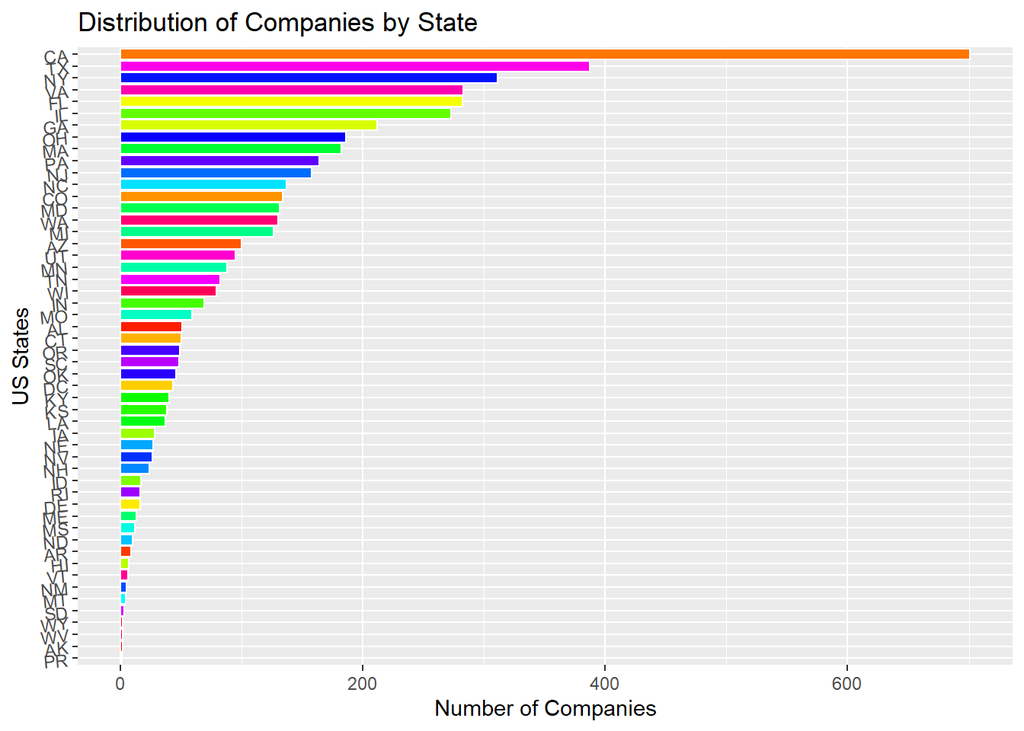

```r
# Answer Question 1 here
# Ask : Give distributions of categorical data: States or Industries.
# We will use a bar which seems to be an intuitive way to present the information. Also bar will provide an comparable view in plot

state_counts <- inc$State %>% table() %>% as.data.frame(stringsAsFactors=FALSE)
colnames(state_counts) <- c('State', 'Frequency')
ggplot(state_counts, aes(x=reorder(State, Frequency),y=Frequency, color=State)) +
  geom_bar(stat='identity', color = 'white', fill=rainbow(52)) +labs(title="Distribution of Companies by State", x="US States", y="Number of Companies")+
  coord_flip() +theme(axis.text.y = element_text(angle = 5))
```